# Post Cleaning Analysis

Daniel Lam

Who is happier?

For this project I will utilize sentiment analysis to gain insights into the HappyDB database that helps answer the question about which groups of people are happier. To do this, I will use the sentimentr package to assign a sentiment score to each entry in the HappyDB database with a more positive score correlating with a more positive sentiment, a more negative score correlating with a more negative sentiment and a score of 0 correlating with a neutral sentiment. I will then split the data on the binary categories of marital, parenthood, and gender.

```r
library(tidyverse)
library(DT)
library(sentimentr)
library(ggplot2)
library(shiny)
```

```r
joined_data <- read_csv("../output/joined_data.csv")
```

Conduct Sentiment analysis using the sentimentr package

```r
sentiment_scores = sentiment_by(joined_data$original_hm, by = NULL)
joined_data$sent_score = sentiment_scores$ave_sentiment
```

Examine data as a whole

```r
cat("Average Sentiment Score: ", mean(joined_data$sent_score), "\nMedian Sentiment Score: ", median(joined_data$sent_score))
```

```
## Average Sentiment Score:  0.2329621
## Median Sentiment Score:  0.2194691
```

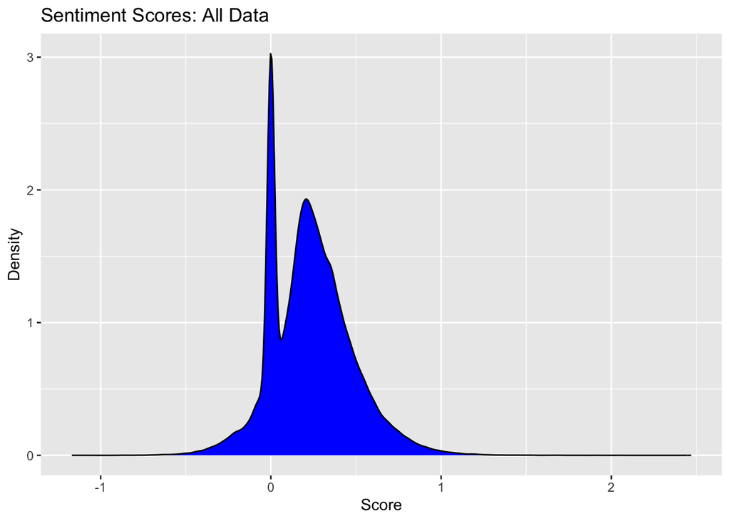

```r
ggplot(joined_data, aes(x = sent_score)) +    #fill = "blue", color = "black"
  geom_density(fill = "blue") +
  labs(title = "Sentiment Scores: All Data", x = "Score", y = "Density")
```

```r
#ggplot(joined_data, aes(x = sent_score)) +
#  geom_histogram(binwidth = 0.1) +
#  labs(title = "Sentiment Scores: All Data", x = "Sentiment Score", y = "Frequency") +
#  theme_minimal()
```

The average and median sentiment scores indicate a positive sentiment throughout the database. I opted to use density plots instead of histograms throughout this project as it will make the slight differences between the population scores more noticeable. The density of the sentiment scores is bi-modal with the first maximum representing the large number of neutral entries which is explained by most of the entries describing an event/occurrence without using emotion-based words. The next maximum is inline with the average and median sentiment scores that were calculated.

Split the data on marital status

```r
df_married = subset(joined_data, marital == 'married')
df_single = subset(joined_data, marital == 'single')

cat("Married entries: ", dim(df_married)[1], "\nSingle entries: ", dim(df_single)[1])
```

```
## Married entries:  40974
## Single entries:  53600
```

```r
cat("Average Married Sentiment Score: ", mean(df_married$sent_score), "\nMedian Married Sentiment Score: ", median(df_married$sent_score))
```

```
## Average Married Sentiment Score:  0.2397973
## Median Married Sentiment Score:  0.2261335
```

```r
cat("Average Single Sentiment Score: ", mean(df_single$sent_score), "\nMedian Single Sentiment Score: ", median(df_single$sent_score))
```

```
## Average Single Sentiment Score:  0.227737
## Median Single Sentiment Score:  0.2145276
```

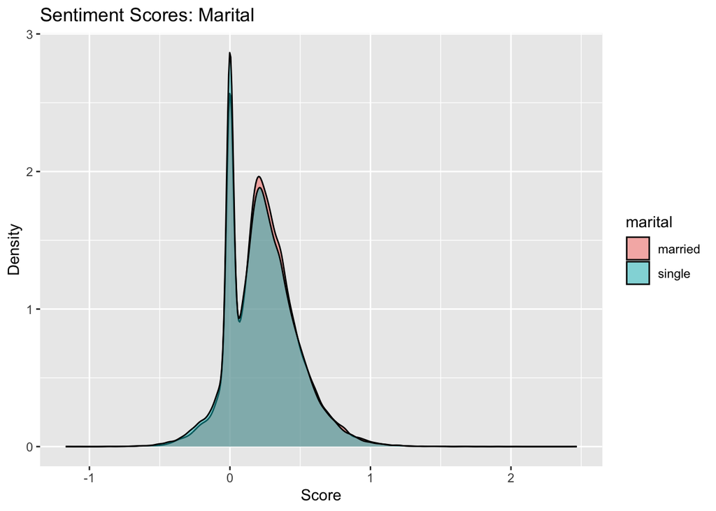

```r
ggplot(joined_data, aes(x = sent_score, fill = marital)) +
  geom_density(alpha = 0.5) +  # Use alpha to make overlapping areas transparent
  labs(title = "Sentiment Scores: Marital", x = "Score", y = "Density")
```

There are more single entries in than married in the database. The data indicates that married people have slightly more positive entries in the database than single people. This is also evident in the overlapping density plots by the peak and slight curve of the married plot outside of the single plot on the second maximum. This is not trivial as there are less entries from married people in the database so the difference can not be explained by more married entries.

Split the data on parenthood status

```r
df_parent = subset(joined_data, parenthood == 'y')
df_notparent = subset(joined_data, parenthood == 'n')

cat("Parent entries: ", dim(df_parent)[1], "\nNon-parent entries: ", dim(df_notparent)[1])
```

```
## Parent entries:  35715
## Non-parent entries:  58859
```

```r
cat("Average Parent Sentiment Score: ", mean(df_parent$sent_score), "\nMedian Parent Sentiment Score: ", median(df_parent$sent_score))
```

```
## Average Parent Sentiment Score:  0.2435865
## Median Parent Sentiment Score:  0.2267787
```

```r
cat("Average Non-parent Sentiment Score: ", mean(df_notparent$sent_score), "\nMedian Non-parent Sentiment Score: ", median(df_notparent$sent_score))
```

```
## Average Non-parent Sentiment Score:  0.2265153
## Median Non-parent Sentiment Score:  0.213809
```

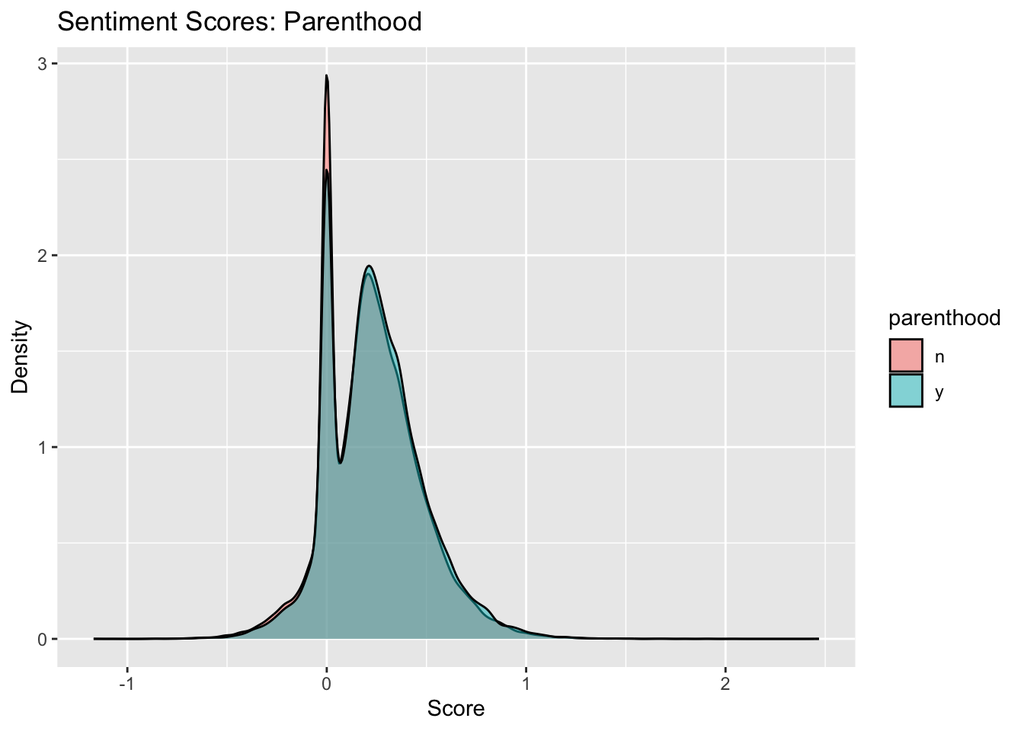

```r
ggplot(joined_data, aes(x = sent_score, fill = parenthood)) +
  geom_density(alpha = 0.5) +  # Use alpha to make overlapping areas transparent
  labs(title = "Sentiment Scores: Parenthood", x = "Score", y = "Density")
```

Split the data on gender

```r
df_m = subset(joined_data, gender == 'm')
df_f = subset(joined_data, gender == 'f')

cat("Average Male Sentiment Score: ", mean(df_m$sent_score), "\nMedian Male Sentiment Score: ", median(df_m$sent_score))
```

```
## Average Male Sentiment Score:  0.2293759
## Median Male Sentiment Score:  0.2165064
```

```r
cat("Average Female Sentiment Score: ", mean(df_f$sent_score), "\nMedian Female Sentiment Score: ", median(df_f$sent_score))
```

```
## Average Female Sentiment Score:  0.2381321
## Median Female Sentiment Score:  0.225
```

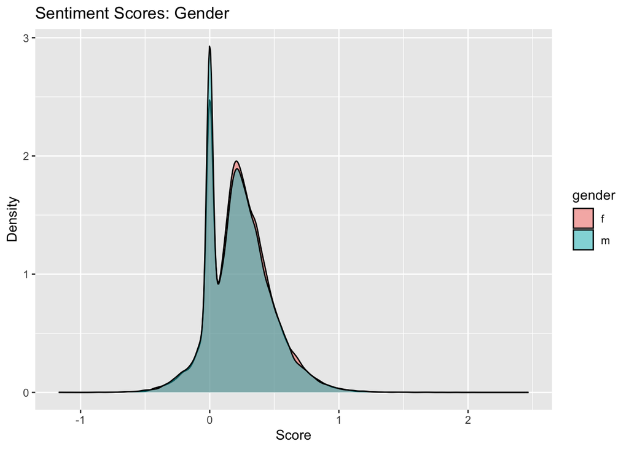

```r
ggplot(joined_data, aes(x = sent_score, fill = gender)) +
  geom_density(alpha = 0.5) +  # Use alpha to make overlapping areas transparent
  labs(title = "Sentiment Scores: Gender", x = "Score", y = "Density")
```

look at sentiment score in correlation with age - ggplot scatter plot subset data on age less than or equal to 100 add a widget that allows you to change the group division - marital, parent, gender

```r
age_df = subset(joined_data, age <=100)
```

[output not shown]

```
##
## Listening on http://127.0.0.1:7490
```

[figure not shown]

```r
# Define the UI
shinyApp(
ui <- fluidPage(
  titlePanel("Age and Sentiment Score"),
  sidebarLayout(
    sidebarPanel(
      selectInput(
        "color_group",
        "Choose Color Group:",
        choices = c("marital", "parenthood", "gender"),
        selected = "marital"
      )
    ),
    mainPanel(
      plotOutput("scatterplot")
    )
  )
),

# Define the server
server <- function(input, output) {

  # Create a reactive expression to generate the scatterplot
  scatterplot_data <- reactive({
    ggplot(age_df, aes(x = age, y = sent_score, color = !!sym(input$color_group))) +
      geom_point() +
      labs(x = "Age", y = "Sentiment Score", color = input$color_group) +
      theme_minimal()
  })

  # Render the scatterplot
  output$scatterplot <- renderPlot({
    print(scatterplot_data())
  })
}

)
```

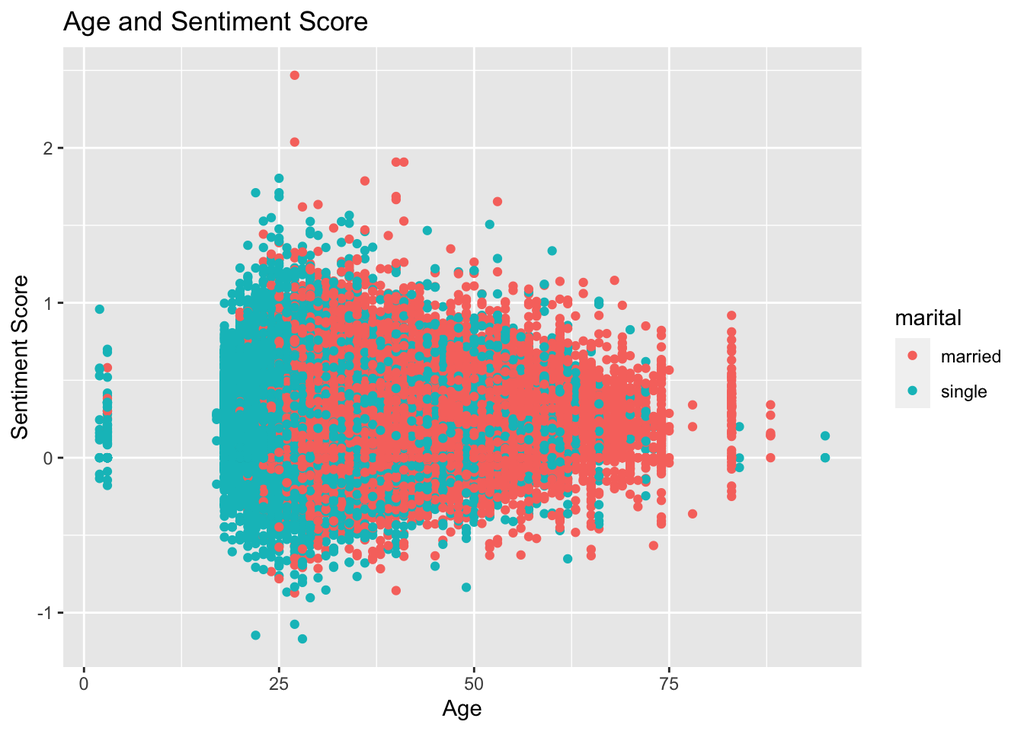

```r
ggplot(age_df, aes(x = age, y = sent_score, color = marital)) +
  geom_point() +
  labs(x = "Age", y = "Sentiment Score", title = "Age and Sentiment Score")
```

```r
summary(joined_data$age)
```

```
##    Min. 1st Qu.  Median    Mean 3rd Qu.    Max.    NA's
##    2.00   25.00   30.00   31.96   35.00  233.00      78
```

```r
subset(joined_data, age == 233)
```

| wid | original_hm | gender | marital | parenthood | reflection_period | age | country | ground_truth_category | text | count | sent_score |
| --- | --- | --- | --- | --- | --- | --- | --- | --- | --- | --- | --- |
| 532 | I found a website that paid really well for the things I do for work. It was a nice and pleasant find. | f | married | y | hours_24 | 233 | USA | NA | found nice paid pleasant website | 5 | 5.791111e-01 |
| 532 | I was approved for a savings account today. I opened it, was approved and deposited some money for something I'm saving for for the next few months. I felt accomplished and happy. | f | married | y | hours_24 | 233 | USA | achievement | accomplished account approved approved deposit im money saved saved | 9 | 5.839161e-01 |
| 532 | My mom and sister and I were laughing about memories together. Was a change from how things normally are in my house. Was nice. | f | married | y | hours_24 | 233 | USA | NA | change house laugh memories mom nice sister | 7 | 1.886849e-01 |
| 532 | My dog's BarkBox came in the mail and it made me happy seeing her excited. | f | married | y | hours_24 | 233 | USA | NA | barkbox dog excited mail | 4 | 3.872983e-01 |
| 532 | I received some cards in the mail by Fairhope, a christian card company. I'm not religious, and i got these for free but the messages were very nice and i enjoyed them. | f | married | y | hours_24 | 233 | USA | NA | card card christian company enjoyed fairhope free im mail message nice received religious | 13 | 6.080509e-01 |
| 532 | I was working today and managed to bring productivity up for a better monthly income. | f | married | y | hours_24 | 233 | USA | NA | bring income managed monthly productive | 5 | 5.293077e-01 |
| 532 | I just got a package of paleo chocolate bars in the mail from my boyfriend as a surprise. | f | married | y | hours_24 | 233 | USA | NA | bar boyfriend chocolate mail package paleo surprise | 7 | 2.828427e-01 |
| 532 | My mom was being hilarious this morning | f | married | y | hours_24 | 233 | USA | NA | hilarious mom morning | 3 | 3.779645e-01 |
| 532 | I woke up to a sweet apology from my boyfriend this morning after a very small argument last night. Also him saying sweet things like i'm always here for you etc | f | married | y | hours_24 | 233 | USA | NA | apologized argument boyfriend im morning night sweet sweet woke | 9 | 1.700983e-01 |
| 532 | When my boyfriend asked me to move in with him in the UK. | f | married | y | months_3 | 233 | USA | NA | boyfriend moved uk | 3 | 0.000000e+00 |

[output cut: 41 more lines]